# Time Series Volume Forecasting

**Author:** Wei Zhang  
**Date:** 8/31/2023

1. Import Data
2. Data Quality Check
3. Exploratory Data Analysis
4. Time Series Data Processing
5. Modeling
6. Forecasting Results

# 1. Import Data

```python
import pandas as pd
import os
import numpy as np
from pylab import rcParams
from datetime import datetime, timedelta
from statsmodels.tsa.seasonal import seasonal_decompose
import matplotlib.pyplot as plt
import seaborn as sns
import pmdarima as pm
from sklearn.metrics import mean_squared_error, mean_absolute_error
from sklearn.model_selection import TimeSeriesSplit
from sklearn.metrics import mean_squared_error
import matplotlib.dates as mdates
import warnings
from sklearn.linear_model import LinearRegression
from statsmodels.graphics.tsaplots import plot_acf, plot_pacf
from statsmodels.tsa.stattools import adfuller
from tqdm import tqdm
from statsmodels.tsa.arima.model import ARIMA
from statsmodels.tsa.statespace.sarimax import SARIMAX
warnings.filterwarnings('ignore')
```

```python
path = os.getcwd() + '/Sample_Data.xlsx'
call = pd.read_excel(path)
```

# 2. Data Quality Check

### 2.1 Overall

```python
call.columns
```

```
Index(['Date', 'Skill ID', 'Group Name', 'Time', 'Contacts Received',
       'AHT of Handled Contacts'],
      dtype='object')
```

```python
call.dtypes
```

```
Date                       datetime64[ns]
Skill ID                          float64
Group Name                         object
Time                               object
Contacts Received                 float64
AHT of Handled Contacts           float64
dtype: object
```

```python
call.shape
```

```
(42240, 6)
```

```python
call.describe()
```

|  | Skill ID | Contacts Received | AHT of Handled Contacts |
| --- | --- | --- | --- |
| count | 42240.0 | 42240.000000 | 42240.000000 |
| mean | 12345.0 | 6.122277 | 354.718537 |
| std | 0.0 | 10.269552 | 569.817693 |
| min | 12345.0 | 0.000000 | 0.000000 |
| 25% | 12345.0 | 0.000000 | 0.000000 |
| 50% | 12345.0 | 0.000000 | 0.000000 |
| 75% | 12345.0 | 10.000000 | 807.000000 |
| max | 12345.0 | 123.000000 | 9701.000000 |

```python
call.info()
```

```
<class 'pandas.core.frame.DataFrame'>
RangeIndex: 42240 entries, 0 to 42239
Data columns (total 6 columns):
 #   Column                   Non-Null Count  Dtype
---  ------                   --------------  -----
 0   Date                     42240 non-null  datetime64[ns]
 1   Skill ID                 42240 non-null  float64
 2   Group Name               42240 non-null  object
 3   Time                     42240 non-null  object
 4   Contacts Received        42240 non-null  float64
 5   AHT of Handled Contacts  42240 non-null  float64
dtypes: datetime64[ns](1), float64(3), object(2)
memory usage: 1.9+ MB
```

```python
#call
```

### 2.2 Date

#### Check Date consistency and gaps

```python
start_date = call.iloc[0, 0]
end_date = call.iloc[42239, 0]

pointer = 0
current_date = start_date
while current_date <= end_date:
    subset = call.iloc[pointer:pointer+48]
    if len(subset) != 48 or not (subset['Date'] == current_date).all():
        print(f"Error at date: {current_date}")
        break
    pointer += 48
    current_date += pd.Timedelta(days=1)
```

The date is consistent and ready for usage.

### 2.3 Skill ID: 12345 42240 times?

```python
call['Skill ID'].value_counts()
```

```
12345.0    42240
Name: Skill ID, dtype: int64
```

### 2.4 Time

#### Check Time range and consistency

```python
if not call['Time'].between(pd.Timestamp('00:00:00').time(),
                           pd.Timestamp('23:30:00').time()).all():
    print("Some times are out of range (00:00:00 to 23:30:00).")
print('All times are in the range (00:00:00 to 23:30:00).')
```

```
All times are in the range (00:00:00 to 23:30:00).
```

```python
current_time = datetime.strptime(str(call.iloc[48,3]), '%H:%M:%S')
current_time

previous_time = datetime.strptime(str(call.iloc[47,3]), '%H:%M:%S')
previous_time

wrap_diff = current_time - previous_time
wrap_diff

wrap_days = 0
previous_time = None
for time in call['Time']:
    time = str(time)
    current_time = datetime.strptime(time, '%H:%M:%S')

    # If previous_time is set, check if the difference is 30 mins
    if previous_time:
        difference = current_time - previous_time
        if difference == wrap_diff:
            wrap_days += 1

        elif difference != timedelta(minutes=30):
            print(f"Error at time: {time_str}. Expected a 30-minute difference, got {difference}.")
    previous_time = current_time

day_range = (end_date - start_date).days
print(f'The time column works:{wrap_days == day_range}.')
day_range
```

```
The time column works:True.
```

```
879
```

### 2.5 Contacts

#### Make sure Contacts Recieved >= 0

```python
call["Contacts Received"].value_counts().sort_index()
```

```
0.0      27289
1.0        324
2.0        247
3.0        336
4.0        412
         ...
82.0         1
86.0         1
102.0        1
118.0        1
123.0        1
Name: Contacts Received, Length: 78, dtype: int64
```

### 2.6 Contacts

#### AHT of Handled Contacts >= 0

```python
call["AHT of Handled Contacts"].value_counts().sort_index()
```

```
0.0       27289
34.0          1
56.0          1
78.0          1
91.0          1
          ...
8793.0        1
8906.0        1
9304.0        1
9628.0        1
9701.0        1
Name: AHT of Handled Contacts, Length: 1799, dtype: int64
```

### 2.7 Add Total Handled Time, NumTime, Year-Month for further analysis needs

```python
call['Total Handled Time'] = call['Contacts Received'] * call['AHT of Handled Contacts']
call = call[['Date', 'Skill ID', 'Group Name', 'Time', 'Contacts Received', 'AHT of Handled Contacts', 'Total Handled Time']]
```

```python
def time_object_to_float(time_obj):
    t = pd.to_datetime(str(time_obj)).time()
    return t.hour + t.minute / 60.0
call['NumTime'] = call['Time'].apply(time_object_to_float)
```

```python
call['Year-Month'] = call['Date'].dt.to_period('M')
call.head()
```

|  | Date | Skill ID | Group Name | Time | Contacts Received | AHT of Handled Contacts | Total Handled Time | NumTime | Year-Month |
| --- | --- | --- | --- | --- | --- | --- | --- | --- | --- |
| 0 | 2021-03-14 | 12345.0 | Priority Customer Service | 00:00:00 | 0.0 | 0.0 | 0.0 | 0.0 | 2021-03 |
| 1 | 2021-03-14 | 12345.0 | Priority Customer Service | 00:30:00 | 0.0 | 0.0 | 0.0 | 0.5 | 2021-03 |
| 2 | 2021-03-14 | 12345.0 | Priority Customer Service | 01:00:00 | 0.0 | 0.0 | 0.0 | 1.0 | 2021-03 |
| 3 | 2021-03-14 | 12345.0 | Priority Customer Service | 01:30:00 | 0.0 | 0.0 | 0.0 | 1.5 | 2021-03 |
| 4 | 2021-03-14 | 12345.0 | Priority Customer Service | 02:00:00 | 0.0 | 0.0 | 0.0 | 2.0 | 2021-03 |

# 3. Exploratory Data Analysis

## 3.1 Hourly Contacts Received

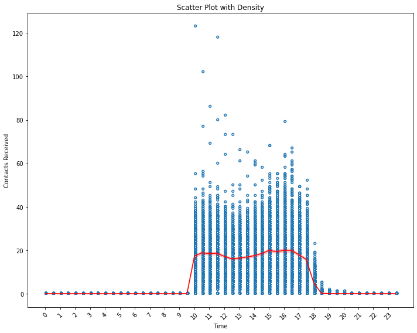

```python
plt.figure(figsize=(10, 8))
sns.scatterplot(data=call, x='NumTime', y='Contacts Received', marker="$\circ$", ec="face", s=50)
sns.lineplot(data=call, x='NumTime', y='Contacts Received', color = 'red')
plt.xticks(ticks=range(0, 24), rotation=45)
plt.xlabel('Time')
plt.ylabel('Contacts Received')
plt.title('Scatter Plot with Density')
plt.tight_layout()
plt.show()
```

The scatter plot above depicts that the majority of the processing times are clustered between 09:00 and 19:00 hours. Notably, there are distinct peaks observed during the morning and afternoon intervals, complemented by noticeable troughs around the lunchtime period.

## 3.2 Hourly AHT

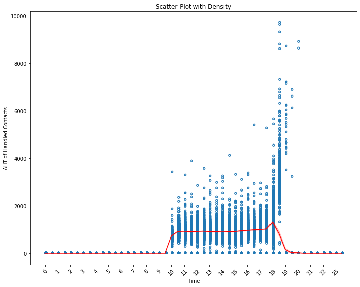

```python
# AHT
plt.figure(figsize=(10, 8))
sns.scatterplot(data=call, x='NumTime', y="AHT of Handled Contacts", marker="$\circ$", ec="face", s=50)
sns.lineplot(data=call, x='NumTime', y="AHT of Handled Contacts", color = 'red')

plt.xticks(ticks=range(0, 24), rotation=45)
plt.xlabel('Time')
plt.ylabel("AHT of Handled Contacts")
plt.title('Scatter Plot with Density')
plt.tight_layout()
plt.show()
```

## 3.3 Aggregate Data Hourly, Weekly and Monthly

### 3.3.1 Hourly

```python
daily_volume = (call.groupby(call['Date'])[['Contacts Received']].sum()
                .reset_index())
daily_HT_AHT = (call.groupby(call['Date'])[['Total Handled Time']].sum()
                .reset_index())
daily_HT_AHT['AHT of Handled Contacts'] = round(daily_HT_AHT['Total Handled Time']/daily_volume['Contacts Received'], 2)
daily_HT_AHT
daily = daily_volume.merge(daily_HT_AHT, on = 'Date')
daily['AHT of Handled Contacts'] = daily['AHT of Handled Contacts'].fillna(0)

daily.head()
```

|  | Date | Contacts Received | Total Handled Time | AHT of Handled Contacts |
| --- | --- | --- | --- | --- |
| 0 | 2021-03-14 | 0.0 | 0.0 | 0.00 |
| 1 | 2021-03-15 | 312.0 | 229908.0 | 736.88 |
| 2 | 2021-03-16 | 0.0 | 0.0 | 0.00 |
| 3 | 2021-03-17 | 273.0 | 219585.0 | 804.34 |
| 4 | 2021-03-18 | 309.0 | 223609.0 | 723.65 |

### 3.3.2 Weekly

```python
#Set weekly end date on Saterday
daily_index = daily.set_index('Date')
daily_HT_AHT_index = daily_HT_AHT.set_index('Date')

weekly_volume = (daily_index.resample('W-SAT')[['Contacts Received']].sum()
                 .reset_index()
                 .rename(columns={'Date':'Week End Date'}))
weekly_HT_AHT = (daily_HT_AHT_index.resample('W-SAT')[['Total Handled Time']].sum()
                 .reset_index()
                 .rename(columns={'Date':'Week End Date'}))

weekly_HT_AHT['AHT of Handled Contacts'] = round(weekly_HT_AHT['Total Handled Time']/weekly_volume['Contacts Received'], 2)
weekly = weekly_volume.merge(weekly_HT_AHT, on = 'Week End Date')
weekly.tail(1)
```

|  | Week End Date | Contacts Received | Total Handled Time | AHT of Handled Contacts |
| --- | --- | --- | --- | --- |
| 125 | 2023-08-12 | 1830.0 | 1894711.0 | 1035.36 |

#### *Filling out last week missing values by replacing values from previous week.

```python
last_row_index = weekly.index[-1]
weekly.loc[last_row_index, 'Contacts Received'] = int(1830 + 461+ 200)
weekly.loc[last_row_index, 'Total Handled Time'] = int((1830 + 461+ 200)*1035.36)
weekly.tail(1)
```

|  | Week End Date | Contacts Received | Total Handled Time | AHT of Handled Contacts |
| --- | --- | --- | --- | --- |
| 125 | 2023-08-12 | 2491.0 | 2579081.0 | 1035.36 |

### 3.3.3 Monthly

```python
monthly_volume = (call.groupby('Year-Month')[['Contacts Received']].sum()
                  .reset_index())
monthly_HT_AHT = (call.groupby('Year-Month')[['Total Handled Time']].sum()
                  .reset_index())
monthly_HT_AHT['AHT of Handled Contacts'] = round(monthly_HT_AHT['Total Handled Time']/monthly_volume['Contacts Received'], 2)
monthly = monthly_volume.merge(monthly_HT_AHT, on = 'Year-Month')
display(monthly.head(1))
monthly.tail(1)
```

|  | Year-Month | Contacts Received | Total Handled Time | AHT of Handled Contacts |
| --- | --- | --- | --- | --- |
| 0 | 2021-03 | 4803.0 | 3688250.0 | 767.91 |

|  | Year-Month | Contacts Received | Total Handled Time | AHT of Handled Contacts |
| --- | --- | --- | --- | --- |
| 29 | 2023-08 | 3902.0 | 4110717.0 | 1053.49 |

#### *Filling out first and last month missing values by average.

```python
last_row_index = monthly.index[-1]
monthly.loc[last_row_index, 'Contacts Received'] = int(3902*3.1)
monthly.loc[last_row_index, 'Total Handled Time'] = int(4110717*3.1)

first_row_index = monthly.index[0]
monthly.loc[first_row_index, 'Contacts Received'] = int(4803/18*31)
monthly.loc[first_row_index, 'Total Handled Time'] = int(4110717/18*31)

display(monthly.head(1))
monthly.tail(1)
```

|  | Year-Month | Contacts Received | Total Handled Time | AHT of Handled Contacts |
| --- | --- | --- | --- | --- |
| 0 | 2021-03 | 8271.0 | 7079568.0 | 767.91 |

|  | Year-Month | Contacts Received | Total Handled Time | AHT of Handled Contacts |
| --- | --- | --- | --- | --- |
| 29 | 2023-08 | 12096.0 | 12743222.0 | 1053.49 |

# 4. Time Series Data Processing

## 4.1 Decomposing

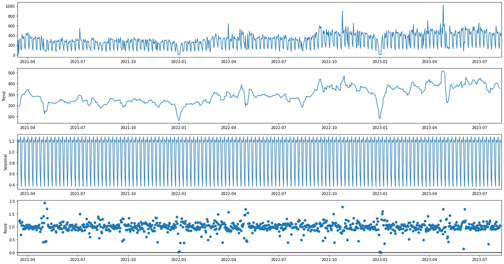

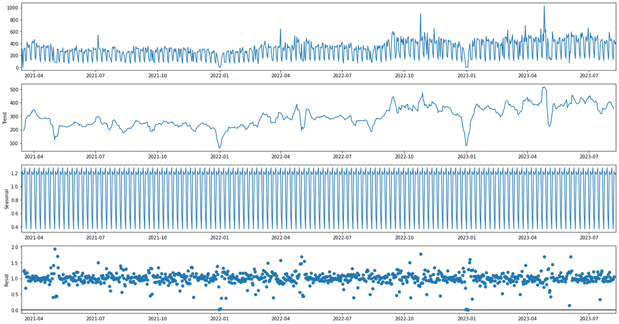

```python
#No Linear Asumption: y(t) = Level * Trend * Seasonality * Noise (Multiplicative model)
#Avoid zero
daily_volume_index = daily_volume.set_index('Date')
decom_daily_volume = daily_volume_index.replace(0, 1)

rcParams['figure.figsize'] = 19, 10
plt.figure(num=None, figsize=(40, 20), dpi=80, facecolor='w', edgecolor='k')
series = decom_daily_volume[:]
result = seasonal_decompose(series, model='multiplicative')
result.plot()
```

## 4.2 Trend

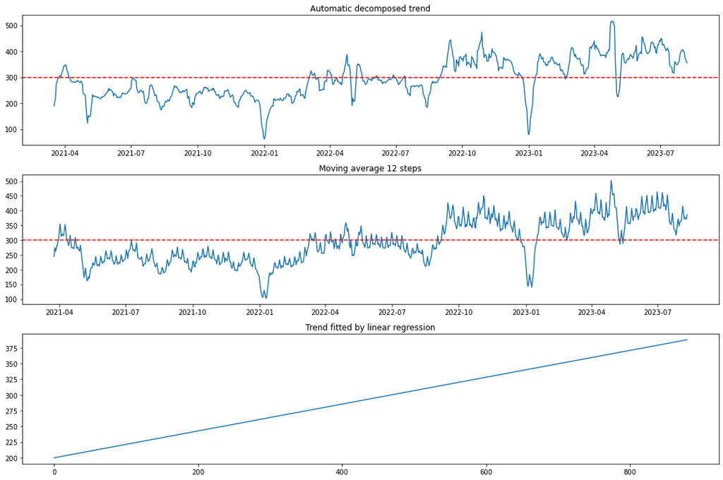

```python
fig = plt.figure(figsize=(15, 10))
layout = (3, 2)
pm_ax = plt.subplot2grid(layout, (0, 0), colspan=2)
mv_ax = plt.subplot2grid(layout, (1, 0), colspan=2)
fit_ax = plt.subplot2grid(layout, (2, 0), colspan=2)

pm_ax.plot(result.trend)
pm_ax.set_title("Automatic decomposed trend")
pm_ax.axhline(y=300, color='red', linestyle='--')

mm = decom_daily_volume.rolling(12).mean()
mv_ax.plot(mm)
mv_ax.set_title("Moving average 12 steps")
mv_ax.axhline(y=300, color='red', linestyle='--')

X = [i for i in range(0, len(decom_daily_volume))]
X = np.reshape(X, (len(X), 1))
y = decom_daily_volume.values
model = LinearRegression()
model.fit(X, y)

# linear regression
trend = model.predict(X)
fit_ax.plot(trend)
fit_ax.set_title("Trend fitted by linear regression")
plt.tight_layout()
```

**In the long term, our daily volume has been gradually increasing, with recent values oscillating around 350.**

## 4.3 Seasonality

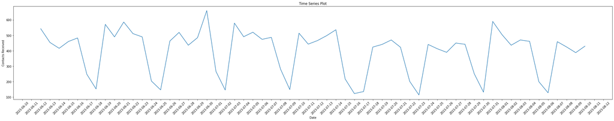

```python
#More detail.
daily_recent_60 = daily.iloc[-60:]

plt.figure(figsize=(30, 6))
sns.lineplot(data=daily_recent_60, x='Date', y='Contacts Received')
plt.title('Time Series Plot')

# Set locator to every day
locator = mdates.DayLocator()
plt.gca().xaxis.set_major_locator(locator)

# Format x-ticks as dates
date_format = mdates.DateFormatter('%Y-%m-%d')
plt.gca().xaxis.set_major_formatter(date_format)

plt.xticks(rotation=45)
plt.tight_layout()

plt.show()
```

```python
daily_volume.tail(10)
```

|  | Date | Contacts Received |
| --- | --- | --- |
| 870 | 2023-08-01 | 505.0 |
| 871 | 2023-08-02 | 436.0 |
| 872 | 2023-08-03 | 470.0 |
| 873 | 2023-08-04 | 461.0 |
| 874 | 2023-08-05 | 200.0 |
| 875 | 2023-08-06 | 128.0 |
| 876 | 2023-08-07 | 459.0 |
| 877 | 2023-08-08 | 425.0 |
| 878 | 2023-08-09 | 388.0 |
| 879 | 2023-08-10 | 430.0 |

```
weekday
Friday       374.560000
Monday       363.761905
Saturday     166.600000
Sunday       106.039683
Thursday     351.555556
Tuesday      347.960317
Wednesday    346.238095
Name: Contacts Received, dtype: float64
```

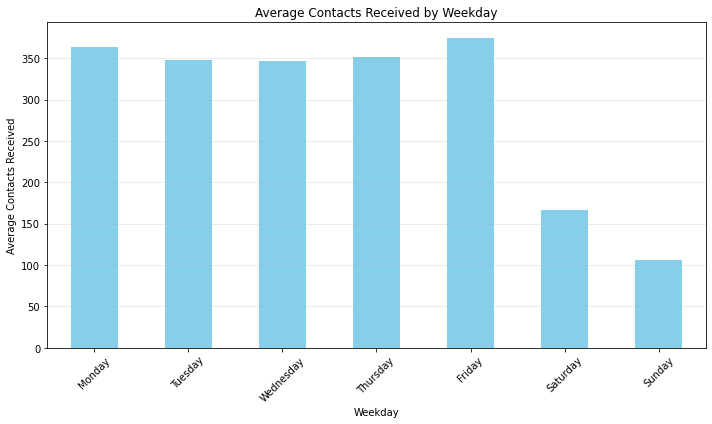

```python
temp_df = daily_volume.copy()
temp_df['Date'] = pd.to_datetime(temp_df['Date'])
temp_df['weekday'] = temp_df['Date'].dt.strftime('%A')
average_contacts = temp_df.groupby('weekday')['Contacts Received'].mean()
print(average_contacts)

#daily_volume['weekday'] =daily_volume.index.strftime("%A")
#daily_volume.groupby('weekday').mean('Contacts Received')

ordered_days = ['Monday', 'Tuesday', 'Wednesday', 'Thursday', 'Friday', 'Saturday', 'Sunday']
average_contacts = average_contacts.reindex(ordered_days)

plt.figure(figsize=(10, 6))
average_contacts.plot(kind='bar', color='skyblue')
plt.title('Average Contacts Received by Weekday')
plt.ylabel('Average Contacts Received')
plt.xlabel('Weekday')
plt.xticks(rotation=45)
plt.tight_layout()
plt.grid(axis='y', linestyle='--', linewidth=0.5, alpha=0.7)
plt.show()
```

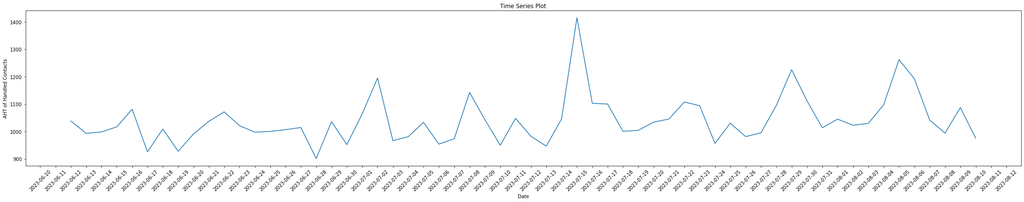

```python
#AHT

daily_recent_60 = daily.iloc[-60:]

plt.figure(figsize=(30, 6))
sns.lineplot(data=daily_recent_60, x='Date', y='AHT of Handled Contacts')
plt.title('Time Series Plot')

# Set locator to every day
locator = mdates.DayLocator()
plt.gca().xaxis.set_major_locator(locator)

# Format x-ticks as dates
date_format = mdates.DateFormatter('%Y-%m-%d')
plt.gca().xaxis.set_major_formatter(date_format)

plt.xticks(rotation=45)
plt.tight_layout()

plt.show()
```

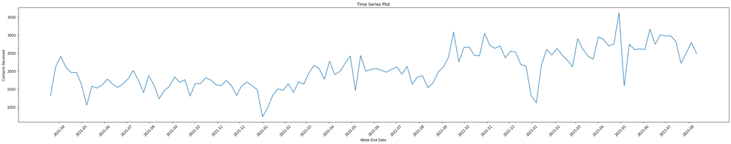

```python
plt.figure(figsize=(30, 6))
sns.lineplot(data=weekly, x='Week End Date', y='Contacts Received')
plt.title('Time Series Plot')

all_months = pd.date_range(start="2021-03-14", end="2023-08-10", freq='MS')
plt.xticks(all_months, all_months.strftime('%Y-%m'), rotation=45)

plt.tight_layout()
plt.show()
```

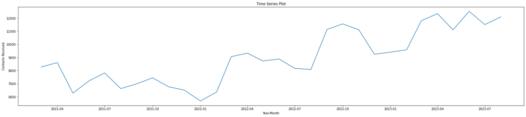

```python
plt.figure(figsize=(30, 6))
sns.lineplot(data=monthly,
             x= pd.to_datetime(monthly['Year-Month'].astype(str)),
             y='Contacts Received')
plt.title('Time Series Plot')
plt.show()
```

**From the monthly and weekly data charts, we can deduce that the contacts have been gradually increasing. The trough was observed in December and January, after which there was a gradual rise. By April, the trend stabilized, and then an increase commenced again in August, continuing until November.**

## 4.4 Noise

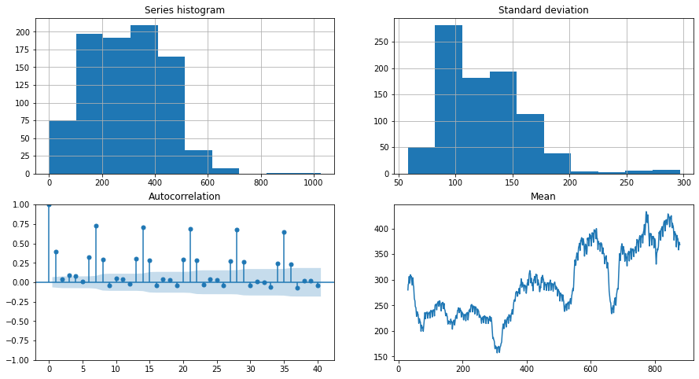

```python
fig = plt.figure(figsize=(15, 8))
layout = (2, 2)
hist_ax = plt.subplot2grid(layout, (0, 0))
ac_ax = plt.subplot2grid(layout, (1, 0))
hist_std_ax = plt.subplot2grid(layout, (0, 1))
mean_ax = plt.subplot2grid(layout, (1, 1))

daily_volume['Contacts Received'].hist(ax=hist_ax)
hist_ax.set_title("Series histogram")

plot_acf(series, lags=40, ax=ac_ax)
ac_ax.set_title("Autocorrelation")

mm = daily_volume['Contacts Received'].rolling(7).std()
mm.hist(ax=hist_std_ax)
hist_std_ax.set_title("Standard deviation")

mm = daily_volume['Contacts Received'].rolling(30).mean()
mm.plot(ax=mean_ax)
mean_ax.set_title("Mean")
```

**1. The histogram of our time series data does not exhibit constant standard deviation, deviating from a Gaussian (normal) distribution.**

**2. The standard deviation is centered around the mean, indicating the presence of a minor component of white noise that cannot be decoupled from the original series.**

**Conclusion: Based on our analysis, the time series contains components of white noise.**

## 4.5 Stationarity

### 4.5.1 Autocorrelation and Partial Autocorrelation Plots

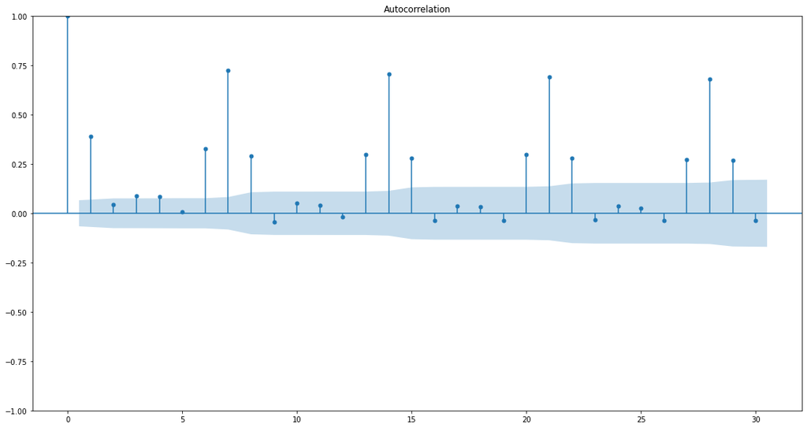

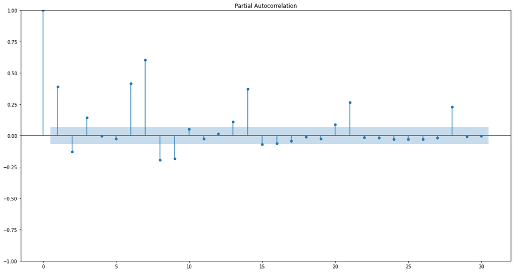

```python
plot_acf(daily_volume['Contacts Received'], lags=30)
plot_pacf(daily_volume['Contacts Received'], lags=30)
plt.show()
```

**From the above plots presented, we observe the following:**

**1. There are significant autocorrelations at lagged time points, suggesting the potential presence of seasonality or long-term trends in the data.**

**2. As the time lag t increases, the autocorrelation values do not exhibit rapid decay.**

**In conclusion, both observations indicate that information persists over time intervals, suggesting that the time series might be non-stationary.**

### 4.5.2 Dickey-Fuller Hypothesis test

**H0: The time series possesses a unit root, indicating non-stationarity.**  
**H1: The time series is stationary.**

**p-value > 0.05: Fail to reject the null hypothesis (H0), the evidence suggests that the time series has a unit root and is therefore non-stationary.**

**p-value <= 0.05: Reject the null hypothesis (H0), indicating that the time series is likely stationary.**

```python
X = daily_volume['Contacts Received'].values
result = adfuller(X)
print('ADF Statistic: %f' % result[0])
print('p-value: %f' % result[1])
print('Critical Values:')
for key, value in result[4].items():
    print('\t%s: %.3f' % (key, value))
# Ignord Making Time Series Stationary since using auto-arima
```

```
ADF Statistic: -2.015131
p-value: 0.279978
Critical Values:
	1%: -3.438
	5%: -2.865
	10%: -2.569
```

**P-value > 0.05, Fail to reject the null hypothesis (H0), the data has a unit root and is non-stationary.**

**Note: In this project, we will using auto-arima, it will internally try different levels of differencing to identify the best model. Thus, we don't have to manually make the series stationary before feeding it to auto-arima.**

# 5. Modeling - ARIMA - SARIMA

## 5.1 Weekly volume forecasting (next 12 weeks)

```python
weekly_volume = weekly[['Week End Date', 'Contacts Received']]
weekly_volume = weekly_volume.set_index('Week End Date')
#weekly_volume
```

```python
# train_test_split
weekly_volume_train = weekly_volume['2021-03-20':'2023-05-20']
weekly_volume_test = weekly_volume['2023-05-27':]
```

```python
#weekly_volume_train
```

```python
#weekly_volume_test
```

### 5.1.1 ARIMA

```python
#auto_arima
autoModel = pm.auto_arima(weekly_volume['Contacts Received'], trace=True, error_action='ignore',
                          suppress_warnings=True, seasonal=True)
autoModel.fit(weekly_volume['Contacts Received'])
```

```
Performing stepwise search to minimize aic
 ARIMA(2,1,2)(0,0,0)[0] intercept   : AIC=inf, Time=0.20 sec
 ARIMA(0,1,0)(0,0,0)[0] intercept   : AIC=1859.361, Time=0.01 sec
 ARIMA(1,1,0)(0,0,0)[0] intercept   : AIC=1839.671, Time=0.03 sec
 ARIMA(0,1,1)(0,0,0)[0] intercept   : AIC=1827.928, Time=0.02 sec
 ARIMA(0,1,0)(0,0,0)[0]             : AIC=1857.427, Time=0.01 sec
 ARIMA(1,1,1)(0,0,0)[0] intercept   : AIC=inf, Time=0.08 sec
 ARIMA(0,1,2)(0,0,0)[0] intercept   : AIC=1828.451, Time=0.04 sec
 ARIMA(1,1,2)(0,0,0)[0] intercept   : AIC=inf, Time=0.12 sec
 ARIMA(0,1,1)(0,0,0)[0]             : AIC=1826.266, Time=0.02 sec
 ARIMA(1,1,1)(0,0,0)[0]             : AIC=1826.407, Time=0.02 sec
 ARIMA(0,1,2)(0,0,0)[0]             : AIC=1827.060, Time=0.02 sec
 ARIMA(1,1,0)(0,0,0)[0]             : AIC=1837.803, Time=0.02 sec
 ARIMA(1,1,2)(0,0,0)[0]             : AIC=1826.425, Time=0.07 sec

Best model:  ARIMA(0,1,1)(0,0,0)[0]
Total fit time: 0.684 seconds
```

```
ARIMA(order=(0, 1, 1), scoring_args={}, suppress_warnings=True,
      with_intercept=False)
```

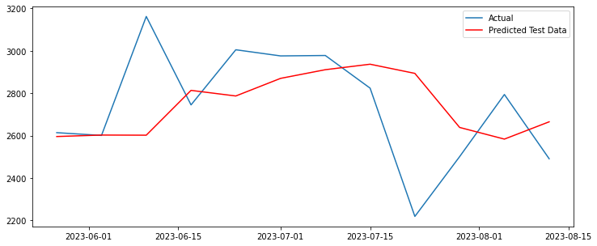

```python
# forecasting on test set
order = autoModel.order
yhat = list()
for t in tqdm(range(len(weekly_volume_test['Contacts Received']))):
    temp_train = weekly_volume[:len(weekly_volume_train)+t]
    model = ARIMA(temp_train['Contacts Received'], order=order)
    weekly_model_fit = model.fit()
    predictions = weekly_model_fit.predict(
        start=len(temp_train), end=len(temp_train), dynamic=False)
    yhat = yhat + [predictions]

yhat = pd.concat(yhat)

yhat

# Test Data against Actual
plt.figure(figsize=(12, 5))
plt.plot(weekly_volume_test.index, weekly_volume_test['Contacts Received'], label='Actual')
plt.plot(weekly_volume_test.index, yhat.values, color='red', label='Predicted Test Data')
plt.legend()
```

```python
# Performance
mae = mean_absolute_error(weekly_volume_test['Contacts Received'], yhat.values)
print(f'The mae of model is:{mae}.')
ape = np.abs(( weekly_volume_test['Contacts Received'] - yhat.values) /  weekly_volume_test['Contacts Received'])
mape=np.mean(ape)
print(f'The mape of model is:{mape}.')
```

```
The mae of model is:195.74233002294613.
The mape of model is:0.07370989004958434.
```

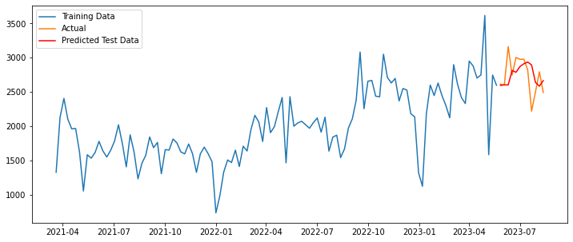

```python
# Overview
plt.figure(figsize=(12, 5))
plt.plot(weekly_volume_train.index, weekly_volume_train['Contacts Received'], label='Training Data')
plt.plot(weekly_volume_test.index, weekly_volume_test['Contacts Received'], label='Actual')
plt.plot(weekly_volume_test.index, yhat.values, color='red', label='Predicted Test Data')
plt.legend()
```

```python
# Forecasting future 12 weeks
last_date = weekly_volume.index[-1]
next_date = last_date + pd.DateOffset(days=7)
new_dates = pd.date_range(start=next_date, periods=12, freq='7D')
new_df = pd.DataFrame(index=new_dates)
extended_df = pd.concat([weekly_volume, new_df])
```

```python
yhat = list()
for t in tqdm(range(len(weekly_volume_test['Contacts Received']))):
    temp_train = extended_df[:len(weekly_volume)+t]
    weekly_model_fit = autoModel.fit(temp_train['Contacts Received'])
    predictions = weekly_model_fit.predict(
        start=len(temp_train), end=len(temp_train), dynamic=False)
    extended_df.iloc[t-12] = predictions.values[0]+120
    yhat = yhat + [predictions.values[0]+120]
#yhat
```

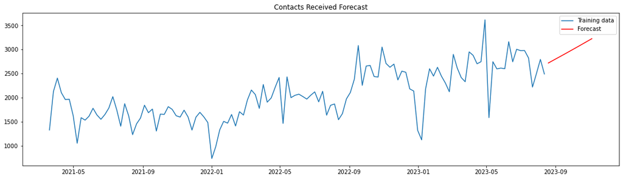

```python
# forecasting overview
plt.figure(figsize=(19, 5))
plt.plot(weekly_volume['Contacts Received'], label='Training data')
future_weeks= pd.date_range('2023-08-19', end='2023-11-04', freq='7D')
plt.plot(future_weeks, yhat, color='red', label='Forecast')
plt.title('Contacts Received Forecast')
plt.legend()
plt.show()
```

**No cyclic patterns showing on further weeks, consider bad performance, need further adjustments.**

### Adjustment

**The underlying idea for this adjustment method involves analyzing historical data to identify analogous cycles.**

**More specifically, we first observe whether there is a regular trend or cycle in the historical data. Then we shall extract periods corresponding to the same week range or month range from the previous year. After performing forecasting on this extracted range, comparisons are made against the actual historical values. Discrepancies observed between the forecasted and actual values are then used to adjust our initial forecast for futre. This ensures that our forecasted data conforms to observed seasonality patterns.**

```python
last_date = weekly_volume.index[-1]
next_date = last_date + pd.DateOffset(days=7)
new_dates = pd.date_range(start=next_date, periods=12, freq='7D')
new_df = pd.DataFrame(index=new_dates)
extended_df2=extended_df[:74]
extended_df2 = pd.concat([extended_df2, new_df])
```

```python
yhat2 = list()
#train+ test
autoModel = pm.auto_arima(extended_df2[:73]['Contacts Received'], trace=True, error_action='ignore',
                          suppress_warnings=True, seasonal=True)
autoModel.fit(weekly_volume['Contacts Received'])

for t in tqdm(range(len(weekly_volume_test['Contacts Received']))):
    temp_train = extended_df2[:73+t]
    weekly_model_fit = autoModel.fit(temp_train['Contacts Received'])
    predictions = weekly_model_fit.predict(
        start=len(temp_train), end=len(temp_train), dynamic=False)
    extended_df2.iloc[t-12] = predictions.values[0]+200
    yhat2 = yhat2 + [predictions.values[0]+200]
#yhat2
```

```
Performing stepwise search to minimize aic
 ARIMA(2,1,2)(0,0,0)[0] intercept   : AIC=inf, Time=0.12 sec
 ARIMA(0,1,0)(0,0,0)[0] intercept   : AIC=1037.242, Time=0.01 sec
 ARIMA(1,1,0)(0,0,0)[0] intercept   : AIC=1029.671, Time=0.04 sec
 ARIMA(0,1,1)(0,0,0)[0] intercept   : AIC=1022.975, Time=0.04 sec
 ARIMA(0,1,0)(0,0,0)[0]             : AIC=1035.282, Time=0.01 sec
 ARIMA(1,1,1)(0,0,0)[0] intercept   : AIC=1023.201, Time=0.06 sec
 ARIMA(0,1,2)(0,0,0)[0] intercept   : AIC=1023.609, Time=0.06 sec
 ARIMA(1,1,2)(0,0,0)[0] intercept   : AIC=inf, Time=0.07 sec
 ARIMA(0,1,1)(0,0,0)[0]             : AIC=1020.988, Time=0.03 sec
 ARIMA(1,1,1)(0,0,0)[0]             : AIC=1021.313, Time=0.03 sec
 ARIMA(0,1,2)(0,0,0)[0]             : AIC=1021.648, Time=0.03 sec
 ARIMA(1,1,0)(0,0,0)[0]             : AIC=1027.709, Time=0.02 sec
 ARIMA(1,1,2)(0,0,0)[0]             : AIC=inf, Time=0.05 sec

Best model:  ARIMA(0,1,1)(0,0,0)[0]
Total fit time: 0.576 seconds
```

```python
#Adjustment
l=[]
for a,b,c in zip(yhat,yhat2,extended_df[73:85].values):
    l.append(a+c-b)
#l
```

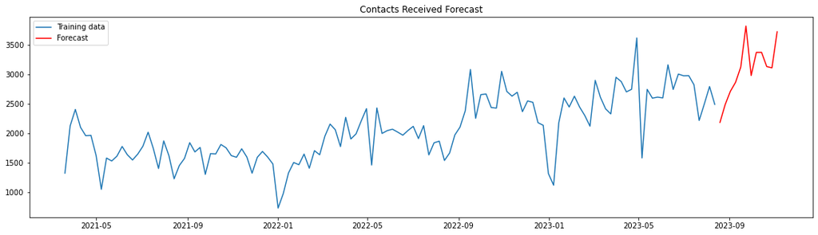

```python
plt.figure(figsize=(19, 5))
#Plotting the historical data
plt.plot(weekly_volume['Contacts Received'], label='Training data')


future_weeks= pd.date_range('2023-08-19', end='2023-11-04', freq='7D')
#display(future_weeks)
plt.plot(future_weeks, l, color='red', label='Forecast')

#Plotting the confidence intervals
#plt.fill_between(pred_w, conf_int.iloc[:, 0], conf_int.iloc[:, 1], color='pink', alpha=0.3)

plt.title('Contacts Received Forecast')
plt.legend()
plt.show()
```

**After the adjustment, the graph shows better performance. We shall check SARIMA for seeking potential higher performance.**

### Forecast Result (ARIMA)

```python
#Forecast Result:
next_12_weeks = pd.DataFrame({'Date': future_weeks, 'Contacts Received':l})
print(next_12_weeks)
```

```
         Date     Contacts Received
0  2023-08-19  [2186.6333141181576]
1  2023-08-26  [2486.9431288230057]
2  2023-09-02   [2712.969209440885]
3  2023-09-09   [2865.026228889268]
4  2023-09-16     [3123.3193766357]
5  2023-09-23  [3819.1507820498614]
6  2023-09-30  [2980.6547183937896]
7  2023-10-07  [3372.1255565648476]
8  2023-10-14   [3373.344264351663]
9  2023-10-21  [3132.2946295086836]
10 2023-10-28  [3110.6886475849647]
11 2023-11-04  [3721.7062338978235]
```

### 5.1.2 SARIMA

```python
autoModel = pm.auto_arima(weekly_volume_train['Contacts Received'], trace=True, error_action='ignore',
                          suppress_warnings=True, seasonal=True, m = 6, stepwise = True)
autoModel.fit(weekly_volume_train['Contacts Received'])
```

```
Performing stepwise search to minimize aic
 ARIMA(2,1,2)(1,0,1)[6] intercept   : AIC=inf, Time=0.28 sec
 ARIMA(0,1,0)(0,0,0)[6] intercept   : AIC=1685.770, Time=0.01 sec
 ARIMA(1,1,0)(1,0,0)[6] intercept   : AIC=1666.043, Time=0.03 sec
 ARIMA(0,1,1)(0,0,1)[6] intercept   : AIC=1657.205, Time=0.06 sec
 ARIMA(0,1,0)(0,0,0)[6]             : AIC=1683.855, Time=0.01 sec
 ARIMA(0,1,1)(0,0,0)[6] intercept   : AIC=1657.452, Time=0.02 sec
 ARIMA(0,1,1)(1,0,1)[6] intercept   : AIC=1658.447, Time=0.14 sec
 ARIMA(0,1,1)(0,0,2)[6] intercept   : AIC=1658.551, Time=0.12 sec
 ARIMA(0,1,1)(1,0,0)[6] intercept   : AIC=1657.391, Time=0.11 sec
 ARIMA(0,1,1)(1,0,2)[6] intercept   : AIC=1660.447, Time=0.28 sec
 ARIMA(0,1,0)(0,0,1)[6] intercept   : AIC=1679.857, Time=0.05 sec
 ARIMA(1,1,1)(0,0,1)[6] intercept   : AIC=inf, Time=0.12 sec
 ARIMA(0,1,2)(0,0,1)[6] intercept   : AIC=1657.565, Time=0.09 sec
 ARIMA(1,1,0)(0,0,1)[6] intercept   : AIC=1665.445, Time=0.05 sec
 ARIMA(1,1,2)(0,0,1)[6] intercept   : AIC=inf, Time=0.21 sec
 ARIMA(0,1,1)(0,0,1)[6]             : AIC=1655.399, Time=0.03 sec
 ARIMA(0,1,1)(0,0,0)[6]             : AIC=1655.808, Time=0.01 sec
 ARIMA(0,1,1)(1,0,1)[6]             : AIC=1656.561, Time=0.15 sec
 ARIMA(0,1,1)(0,0,2)[6]             : AIC=1656.732, Time=0.12 sec
 ARIMA(0,1,1)(1,0,0)[6]             : AIC=1655.587, Time=0.02 sec
 ARIMA(0,1,1)(1,0,2)[6]             : AIC=1658.561, Time=0.17 sec
 ARIMA(0,1,0)(0,0,1)[6]             : AIC=1677.884, Time=0.04 sec
 ARIMA(1,1,1)(0,0,1)[6]             : AIC=1652.985, Time=0.08 sec
 ARIMA(1,1,1)(0,0,0)[6]             : AIC=1656.340, Time=0.03 sec
 ARIMA(1,1,1)(1,0,1)[6]             : AIC=1655.258, Time=0.12 sec
 ARIMA(1,1,1)(0,0,2)[6]             : AIC=1652.738, Time=0.13 sec
 ARIMA(1,1,1)(1,0,2)[6]             : AIC=1652.177, Time=0.28 sec
 ARIMA(1,1,1)(2,0,2)[6]             : AIC=1652.138, Time=0.25 sec
 ARIMA(1,1,1)(2,0,1)[6]             : AIC=1657.065, Time=0.21 sec
 ARIMA(0,1,1)(2,0,2)[6]             : AIC=1656.400, Time=0.19 sec
 ARIMA(1,1,0)(2,0,2)[6]             : AIC=1662.646, Time=0.16 sec
 ARIMA(2,1,1)(2,0,2)[6]             : AIC=1652.340, Time=0.31 sec
 ARIMA(1,1,2)(2,0,2)[6]             : AIC=1652.392, Time=0.35 sec
 ARIMA(0,1,0)(2,0,2)[6]             : AIC=1675.353, Time=0.13 sec
 ARIMA(0,1,2)(2,0,2)[6]             : AIC=1656.507, Time=0.24 sec
 ARIMA(2,1,0)(2,0,2)[6]             : AIC=1659.785, Time=0.25 sec
 ARIMA(2,1,2)(2,0,2)[6]             : AIC=1654.040, Time=0.42 sec
 ARIMA(1,1,1)(2,0,2)[6] intercept   : AIC=1651.005, Time=0.35 sec
 ARIMA(1,1,1)(1,0,2)[6] intercept   : AIC=inf, Time=0.32 sec
 ARIMA(1,1,1)(2,0,1)[6] intercept   : AIC=inf, Time=0.31 sec
 ARIMA(1,1,1)(1,0,1)[6] intercept   : AIC=inf, Time=0.19 sec
 ARIMA(0,1,1)(2,0,2)[6] intercept   : AIC=1658.298, Time=0.27 sec
 ARIMA(1,1,0)(2,0,2)[6] intercept   : AIC=1664.585, Time=0.18 sec
 ARIMA(2,1,1)(2,0,2)[6] intercept   : AIC=1650.813, Time=0.42 sec
 ARIMA(2,1,1)(1,0,2)[6] intercept   : AIC=inf, Time=0.34 sec
 ARIMA(2,1,1)(2,0,1)[6] intercept   : AIC=inf, Time=0.38 sec
 ARIMA(2,1,1)(1,0,1)[6] intercept   : AIC=inf, Time=0.24 sec
 ARIMA(2,1,0)(2,0,2)[6] intercept   : AIC=1661.743, Time=0.27 sec
 ARIMA(3,1,1)(2,0,2)[6] intercept   : AIC=inf, Time=0.43 sec
 ARIMA(2,1,2)(2,0,2)[6] intercept   : AIC=inf, Time=0.42 sec
 ARIMA(1,1,2)(2,0,2)[6] intercept   : AIC=inf, Time=0.44 sec
 ARIMA(3,1,0)(2,0,2)[6] intercept   : AIC=1663.426, Time=0.32 sec
 ARIMA(3,1,2)(2,0,2)[6] intercept   : AIC=inf, Time=0.45 sec

Best model:  ARIMA(2,1,1)(2,0,2)[6] intercept
Total fit time: 10.634 seconds
```

```
ARIMA(order=(2, 1, 1), scoring_args={}, seasonal_order=(2, 0, 2, 6),
      suppress_warnings=True)
```

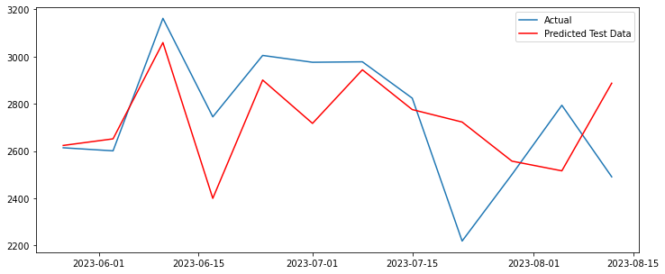

```python
order = autoModel.order
seasonalOrder = autoModel.seasonal_order
yhat = list()
for t in tqdm(range(len(weekly_volume_test['Contacts Received']))):
    temp_train = weekly_volume[:len(weekly_volume_train)+t]
    model = SARIMAX(temp_train['Contacts Received'], order=order,
                    seasonal_order=seasonalOrder)
    s_weekly_model_fit = model.fit(disp=False)
    predictions = s_weekly_model_fit.predict(
        start=len(temp_train), end=len(temp_train), dynamic=False)
    yhat = yhat + [predictions]
yhat = pd.concat(yhat)

plt.figure(figsize=(12, 5))
plt.plot(weekly_volume_test.index, weekly_volume_test['Contacts Received'], label='Actual')
plt.plot(weekly_volume_test.index, yhat.values, color='red', label='Predicted Test Data')
plt.legend()
```

```python
mae = mean_absolute_error(weekly_volume_test['Contacts Received'], yhat.values)
print(f'The mae of model is:{mae}.')
ape = np.abs(( weekly_volume_test['Contacts Received'] - yhat.values) /  weekly_volume_test['Contacts Received'])
mape=np.mean(ape)
print(f'The mape of model is:{mape}.')
```

```
The mae of model is:182.3050540963982.
The mape of model is:0.0699700788900452.
```

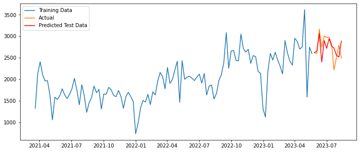

```python
plt.figure(figsize=(12, 5))

plt.plot(weekly_volume_train.index, weekly_volume_train['Contacts Received'], label='Training Data')
plt.plot(weekly_volume_test.index, weekly_volume_test['Contacts Received'], label='Actual')
plt.plot(weekly_volume_test.index, yhat.values, color='red', label='Predicted Test Data')
plt.legend()
```

```python
#Future 12 weeks

last_date = weekly_volume.index[-1]
next_date = last_date + pd.DateOffset(days=7)
new_dates = pd.date_range(start=next_date, periods=12, freq='7D')
new_df = pd.DataFrame(index=new_dates)
extended_df = pd.concat([weekly_volume, new_df])
```

```python
yhat = list()
for t in tqdm(range(len(weekly_volume_test['Contacts Received']))):
    temp_train = extended_df[:len(weekly_volume)+t]

    s_weekly_model_fit = autoModel.fit(temp_train['Contacts Received'])
    predictions = s_weekly_model_fit.predict(
        start=len(temp_train), end=len(temp_train), dynamic=False)
    extended_df.iloc[t-12] = predictions.values[0]+120
    yhat = yhat + [predictions.values[0]+120]

#yhat
```

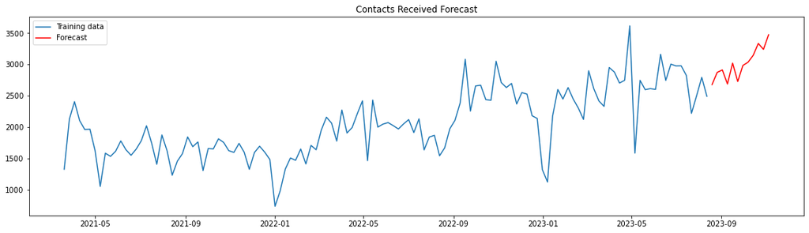

```python
plt.figure(figsize=(19, 5))
#Plotting the historical data
plt.plot(weekly_volume['Contacts Received'], label='Training data')


future_weeks= pd.date_range('2023-08-19', end='2023-11-04', freq='7D')
#display(future_weeks)
plt.plot(future_weeks, yhat, color='red', label='Forecast')

#Plotting the confidence intervals
#plt.fill_between(pred_w, conf_int.iloc[:, 0], conf_int.iloc[:, 1], color='pink', alpha=0.3)

plt.title('Contacts Received Forecast')
plt.legend()
plt.show()
```

### Adjustment

```python
last_date = weekly_volume.index[-1]
next_date = last_date + pd.DateOffset(days=7)
new_dates = pd.date_range(start=next_date, periods=12, freq='7D')
new_df = pd.DataFrame(index=new_dates)
extended_df2=extended_df[:74]
extended_df2 = pd.concat([extended_df2, new_df])
```

```python
yhat2 = list()
#train+ test
autoModel = pm.auto_arima(extended_df2[:73]['Contacts Received'], trace=True, error_action='ignore',
                          suppress_warnings=True, seasonal=True)
autoModel.fit(weekly_volume['Contacts Received'])

for t in tqdm(range(len(weekly_volume_test['Contacts Received']))):
    temp_train = extended_df2[:73+t]

    s_weekly_model_fit = autoModel.fit(temp_train['Contacts Received'])
    predictions = s_weekly_model_fit.predict(
        start=len(temp_train), end=len(temp_train), dynamic=False)
    extended_df2.iloc[t-12] = predictions.values[0]+200
    yhat2 = yhat2 + [predictions.values[0]+200]

#yhat2
```

```
Performing stepwise search to minimize aic
 ARIMA(2,1,2)(0,0,0)[0] intercept   : AIC=inf, Time=0.11 sec
 ARIMA(0,1,0)(0,0,0)[0] intercept   : AIC=1037.242, Time=0.01 sec
 ARIMA(1,1,0)(0,0,0)[0] intercept   : AIC=1029.671, Time=0.04 sec
 ARIMA(0,1,1)(0,0,0)[0] intercept   : AIC=1022.975, Time=0.04 sec
 ARIMA(0,1,0)(0,0,0)[0]             : AIC=1035.282, Time=0.01 sec
 ARIMA(1,1,1)(0,0,0)[0] intercept   : AIC=1023.201, Time=0.05 sec
 ARIMA(0,1,2)(0,0,0)[0] intercept   : AIC=1023.609, Time=0.05 sec
 ARIMA(1,1,2)(0,0,0)[0] intercept   : AIC=inf, Time=0.06 sec
 ARIMA(0,1,1)(0,0,0)[0]             : AIC=1020.988, Time=0.02 sec
 ARIMA(1,1,1)(0,0,0)[0]             : AIC=1021.313, Time=0.03 sec
 ARIMA(0,1,2)(0,0,0)[0]             : AIC=1021.648, Time=0.03 sec
 ARIMA(1,1,0)(0,0,0)[0]             : AIC=1027.709, Time=0.02 sec
 ARIMA(1,1,2)(0,0,0)[0]             : AIC=inf, Time=0.05 sec

Best model:  ARIMA(0,1,1)(0,0,0)[0]
Total fit time: 0.522 seconds
```

```python
l=[]
for a,b,c in zip(yhat,yhat2,extended_df[73:85].values):
    l.append(a+c-b)
#l
```

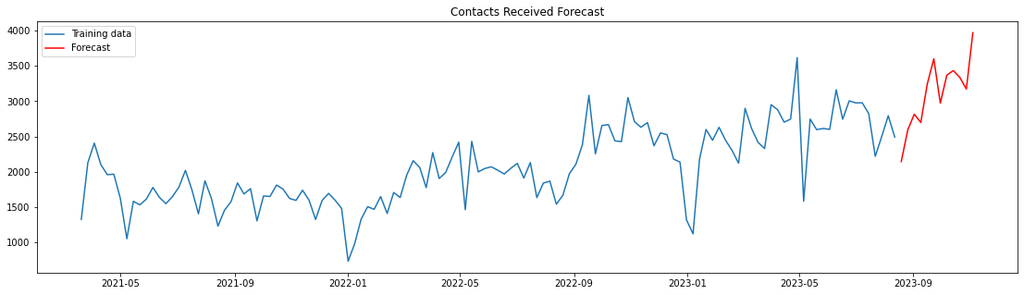

```python
plt.figure(figsize=(19, 5))
#Plotting the historical data
plt.plot(weekly_volume['Contacts Received'], label='Training data')
future_weeks= pd.date_range('2023-08-19', end='2023-11-04', freq='7D')
#display(future_weeks)
plt.plot(future_weeks, l, color='red', label='Forecast')

#Plotting the confidence intervals
#plt.fill_between(pred_w, conf_int.iloc[:, 0], conf_int.iloc[:, 1], color='pink', alpha=0.3)

plt.title('Contacts Received Forecast')
plt.legend()
plt.show()
```

### Forecast Result (SARIMA)

```python
#Forecast Result:
next_best_12_weeks = pd.DataFrame({'Date': future_weeks, 'Contacts Received':l})
print(next_best_12_weeks)
```

```
         Date     Contacts Received
0  2023-08-19  [2145.5596098233664]
1  2023-08-26   [2594.888898521796]
2  2023-09-02   [2815.695276223471]
3  2023-09-09   [2698.087080518644]
4  2023-09-16  [3244.6706809202024]
5  2023-09-23   [3600.857096726862]
6  2023-09-30  [2972.7332218161696]
7  2023-10-07  [3369.2068539494608]
8  2023-10-14  [3433.3833137508072]
9  2023-10-21  [3336.2536557468006]
10 2023-10-28    [3172.71556621232]
11 2023-11-04  [3970.2202071516645]
```

## 5.2 Monthly Volume forecasting (next 18 months)

```python
monthly_volume = monthly[['Year-Month', 'Contacts Received']]
monthly_volume = monthly_volume.set_index('Year-Month')
monthly_volume.index = monthly_volume.index.to_timestamp().strftime('%Y-%m-%d')
```

```python
#train-test split
monthly_volume_train = monthly_volume.iloc[0:27]
monthly_volume_test = monthly_volume[27:]
```

### 5.2.1 ARIMA

```python
autoModel = pm.auto_arima(monthly_volume_train['Contacts Received'], trace=True, error_action='ignore',
                          suppress_warnings=True, seasonal=True)
autoModel.fit(monthly_volume_train['Contacts Received'])
```

```
Performing stepwise search to minimize aic
 ARIMA(2,1,2)(0,0,0)[0] intercept   : AIC=inf, Time=0.08 sec
 ARIMA(0,1,0)(0,0,0)[0] intercept   : AIC=446.960, Time=0.01 sec
 ARIMA(1,1,0)(0,0,0)[0] intercept   : AIC=448.936, Time=0.02 sec
 ARIMA(0,1,1)(0,0,0)[0] intercept   : AIC=448.921, Time=0.01 sec
 ARIMA(0,1,0)(0,0,0)[0]             : AIC=445.170, Time=0.01 sec
 ARIMA(1,1,1)(0,0,0)[0] intercept   : AIC=inf, Time=0.07 sec

Best model:  ARIMA(0,1,0)(0,0,0)[0]
Total fit time: 0.203 seconds
```

```
ARIMA(order=(0, 1, 0), scoring_args={}, suppress_warnings=True,
      with_intercept=False)
```

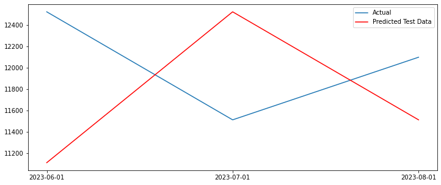

```python
order = autoModel.order
yhat = list()
for t in tqdm(range(len(monthly_volume_test['Contacts Received']))):
    temp_train = monthly_volume[:len(monthly_volume_train)+t]
    model = ARIMA(temp_train['Contacts Received'], order=order)
    monthly_model_fit = model.fit()
    predictions = monthly_model_fit.predict(
        start=len(temp_train), end=len(temp_train), dynamic=False)
    yhat = yhat + [predictions]

yhat = pd.concat(yhat)

yhat

plt.figure(figsize=(12, 5))
#plt.plot(monthly_volume_train.index.to_timestamp(), monthly_volume_train['Contacts Received'], label='Training Data')
plt.plot(monthly_volume_test.index, monthly_volume_test['Contacts Received'], label='Actual')
plt.plot(monthly_volume_test.index, yhat.values, color='red', label='Predicted Test Data')
plt.legend()
```

```python
mae = mean_absolute_error(monthly_volume_test['Contacts Received'], yhat.values)
print(f'The mae of model is:{mae}.')
ape = np.abs(( monthly_volume_test['Contacts Received'] - yhat.values) / monthly_volume_test['Contacts Received'])
mape=np.mean(ape)
print(f'The mape of model is:{mape}.')
```

```
The mae of model is:1003.0.
The mape of model is:0.08301765881666301.
```

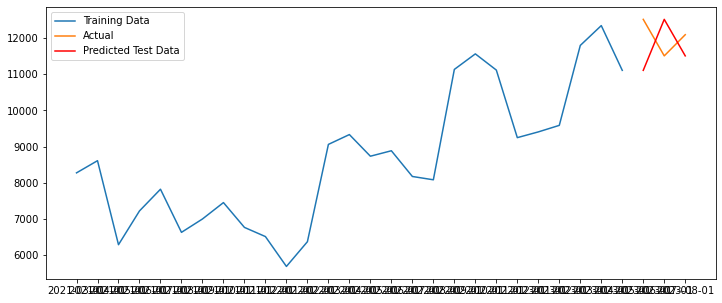

```python
plt.figure(figsize=(12, 5))
plt.plot(monthly_volume_train.index, monthly_volume_train['Contacts Received'], label='Training Data')
plt.plot(monthly_volume_test.index, monthly_volume_test['Contacts Received'], label='Actual')
plt.plot(monthly_volume_test.index, yhat.values, color='red', label='Predicted Test Data')
plt.legend()
```

```python
#Future 18 months

last_month_datetime = pd.to_datetime(monthly_volume.index[-1])
next_month_datetime = last_month_datetime + pd.DateOffset(months=1)
next_month_str = next_month_datetime.strftime('%Y-%m-%d')
next_month_str
new_months = pd.date_range(start=next_month_str, periods=18, freq='MS')
new_df = pd.DataFrame(index=new_months)
extended_df = pd.concat([monthly_volume, new_df])
```

```python
yhat = list()
for t in tqdm(range(18)):
    temp_train = extended_df[:len(monthly_volume)+t]

    monthly_model_fit = autoModel.fit(temp_train['Contacts Received'])


    predictions = monthly_model_fit.predict(
        start=len(temp_train), end=len(temp_train), dynamic=False)
    extended_df.iloc[t-18] = predictions.values[0]+120
    yhat = yhat + [predictions.values[0]+120]

#yhat
```

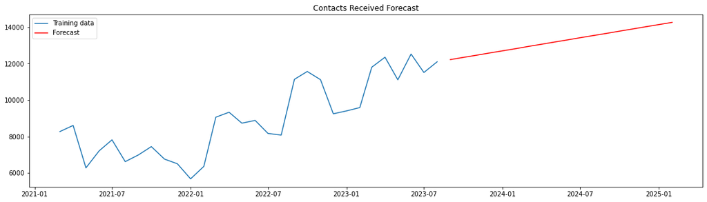

```python
plt.figure(figsize=(19, 5))
#Plotting the historical data
monthly_volume.index = pd.to_datetime(monthly_volume.index)
plt.plot(monthly_volume['Contacts Received'], label='Training data')


future_months= pd.date_range(start=next_month_datetime, periods=18, freq='MS')
#display(future_weeks)
plt.plot(future_months, yhat, color='red', label='Forecast')

#Plotting the confidence intervals
#plt.fill_between(pred_w, conf_int.iloc[:, 0], conf_int.iloc[:, 1], color='pink', alpha=0.3)

plt.title('Contacts Received Forecast')
plt.legend()
plt.show()
```

### Adjustment

```python
last_month_datetime = pd.to_datetime(monthly_volume.index[-1])
next_month_datetime = last_month_datetime + pd.DateOffset(months=1)
next_month_str = next_month_datetime.strftime('%Y-%m-%d')
new_months = pd.date_range(start=next_month_str, periods=18, freq='MS')
new_df = pd.DataFrame(index=new_months)
extended_df2 = extended_df[:18]
extended_df2 = pd.concat([extended_df2, new_df])
```

```python
yhat2 = list()
#train+ test
autoModel = pm.auto_arima(extended_df2[:17]['Contacts Received'], trace=True, error_action='ignore',
                          suppress_warnings=True, seasonal=True)
autoModel.fit(monthly_volume['Contacts Received'])


for t in tqdm(range(18)):
    temp_train = extended_df2[:17+t]

    monthly_model_fit = autoModel.fit(temp_train['Contacts Received'])


    predictions = monthly_model_fit.predict(
        start=len(temp_train), end=len(temp_train), dynamic=False)
    extended_df2.iloc[t-18] = predictions.values[0]+200
    yhat2 = yhat2 + [predictions.values[0]+200]

#yhat2
```

```
Performing stepwise search to minimize aic
 ARIMA(2,0,2)(0,0,0)[0] intercept   : AIC=inf, Time=0.06 sec
 ARIMA(0,0,0)(0,0,0)[0] intercept   : AIC=290.054, Time=0.01 sec
 ARIMA(1,0,0)(0,0,0)[0] intercept   : AIC=286.664, Time=0.02 sec
 ARIMA(0,0,1)(0,0,0)[0] intercept   : AIC=inf, Time=0.02 sec
 ARIMA(0,0,0)(0,0,0)[0]             : AIC=354.295, Time=0.01 sec
 ARIMA(2,0,0)(0,0,0)[0] intercept   : AIC=287.903, Time=0.02 sec
 ARIMA(1,0,1)(0,0,0)[0] intercept   : AIC=288.492, Time=0.02 sec
 ARIMA(2,0,1)(0,0,0)[0] intercept   : AIC=inf, Time=0.08 sec
 ARIMA(1,0,0)(0,0,0)[0]             : AIC=inf, Time=0.01 sec

Best model:  ARIMA(1,0,0)(0,0,0)[0] intercept
Total fit time: 0.231 seconds
```

```python
l=[]
for a,b,c in zip(yhat,yhat2,extended_df[17:35].values):
    l.append(a+c-b)
#l
```

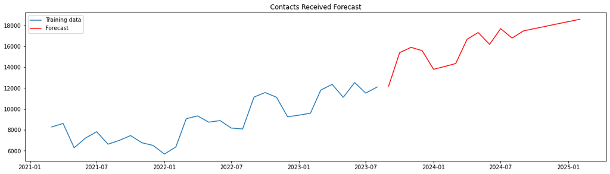

```python
plt.figure(figsize=(19, 5))
monthly_volume.index = pd.to_datetime(monthly_volume.index)
plt.plot(monthly_volume['Contacts Received'], label='Training data')
future_months= pd.date_range(start=next_month_datetime, periods=18, freq='MS')
plt.plot(future_months, l, color='red', label='Forecast')
plt.title('Contacts Received Forecast')
plt.legend()
plt.show()
```

### Forecast Result (ARIMA)

```python
next_18_months = pd.DataFrame({'Date': future_months, 'Contacts Received':l})
print(next_18_months)
```

```
         Date     Contacts Received
0  2023-09-01  [12166.547145081646]
1  2023-10-01  [15381.795160444159]
2  2023-11-01  [15890.230448480179]
3  2023-12-01  [15574.594641380487]
4  2024-01-01  [13788.986505672396]
5  2024-02-01  [14066.265562978213]
6  2024-03-01  [14337.896636709047]
7  2024-04-01  [16661.721183084413]
8  2024-05-01   [17305.10369683244]
9  2024-06-01  [16172.996881628736]
10 2024-07-01   [17682.02574721393]
11 2024-08-01  [16775.893692219634]
12 2024-09-01   [17460.79041558978]
13 2024-10-01   [17684.67752710487]
14 2024-11-01    [17904.9216964358]
15 2024-12-01   [18128.37245051967]
16 2025-01-01   [18349.59786232761]
17 2025-02-01   [18572.91342544071]
```

### 5.2.2 SARIMA

```python
autoModel = pm.auto_arima(monthly_volume_train['Contacts Received'], trace=True, error_action='ignore',
                          suppress_warnings=True, seasonal=True, m =6, stepwise = True)
autoModel.fit(monthly_volume_train['Contacts Received'])
```

```
Performing stepwise search to minimize aic
 ARIMA(2,0,2)(1,1,1)[6] intercept   : AIC=343.467, Time=0.16 sec
 ARIMA(0,0,0)(0,1,0)[6] intercept   : AIC=366.283, Time=0.01 sec
 ARIMA(1,0,0)(1,1,0)[6] intercept   : AIC=344.838, Time=0.08 sec
 ARIMA(0,0,1)(0,1,1)[6] intercept   : AIC=inf, Time=0.07 sec
 ARIMA(0,0,0)(0,1,0)[6]             : AIC=371.865, Time=0.01 sec
 ARIMA(2,0,2)(0,1,1)[6] intercept   : AIC=inf, Time=0.14 sec
 ARIMA(2,0,2)(1,1,0)[6] intercept   : AIC=348.444, Time=0.06 sec
 ARIMA(2,0,2)(2,1,1)[6] intercept   : AIC=345.808, Time=0.26 sec
 ARIMA(2,0,2)(1,1,2)[6] intercept   : AIC=345.129, Time=0.27 sec
 ARIMA(2,0,2)(0,1,0)[6] intercept   : AIC=363.705, Time=0.08 sec
 ARIMA(2,0,2)(0,1,2)[6] intercept   : AIC=341.567, Time=0.21 sec
 ARIMA(1,0,2)(0,1,2)[6] intercept   : AIC=inf, Time=0.19 sec
 ARIMA(2,0,1)(0,1,2)[6] intercept   : AIC=341.565, Time=0.19 sec
 ARIMA(2,0,1)(0,1,1)[6] intercept   : AIC=343.057, Time=0.13 sec
 ARIMA(2,0,1)(1,1,2)[6] intercept   : AIC=350.214, Time=0.22 sec
 ARIMA(2,0,1)(1,1,1)[6] intercept   : AIC=342.283, Time=0.14 sec
 ARIMA(1,0,1)(0,1,2)[6] intercept   : AIC=339.543, Time=0.20 sec
 ARIMA(1,0,1)(0,1,1)[6] intercept   : AIC=inf, Time=0.10 sec
 ARIMA(1,0,1)(1,1,2)[6] intercept   : AIC=341.859, Time=0.26 sec
 ARIMA(1,0,1)(1,1,1)[6] intercept   : AIC=341.316, Time=0.13 sec
 ARIMA(0,0,1)(0,1,2)[6] intercept   : AIC=inf, Time=0.16 sec
 ARIMA(1,0,0)(0,1,2)[6] intercept   : AIC=inf, Time=0.11 sec
 ARIMA(0,0,0)(0,1,2)[6] intercept   : AIC=inf, Time=0.11 sec
 ARIMA(0,0,2)(0,1,2)[6] intercept   : AIC=inf, Time=0.16 sec
 ARIMA(2,0,0)(0,1,2)[6] intercept   : AIC=inf, Time=0.14 sec
 ARIMA(1,0,1)(0,1,2)[6]             : AIC=340.307, Time=0.13 sec

Best model:  ARIMA(1,0,1)(0,1,2)[6] intercept
Total fit time: 3.716 seconds
```

```
ARIMA(order=(1, 0, 1), scoring_args={}, seasonal_order=(0, 1, 2, 6),
      suppress_warnings=True)
```

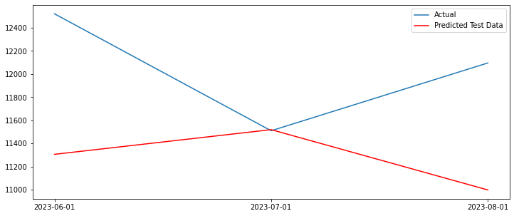

```python
order = autoModel.order
seasonalOrder = autoModel.seasonal_order
yhat = list()
for t in tqdm(range(len(monthly_volume_test['Contacts Received']))):
    temp_train = monthly_volume[:len(monthly_volume_train)+t]
    model = SARIMAX(temp_train['Contacts Received'], order=order,
                    seasonal_order=seasonalOrder)
    s_monthly_model_fit = model.fit(disp=False)
    predictions = s_monthly_model_fit.predict(
        start=len(temp_train), end=len(temp_train), dynamic=False)
    yhat = yhat + [predictions]
yhat = pd.concat(yhat)

plt.figure(figsize=(12, 5))
plt.plot(monthly_volume_test.index, monthly_volume_test['Contacts Received'], label='Actual')
plt.plot(monthly_volume_test.index, yhat.values, color='red', label='Predicted Test Data')
plt.legend()
```

```python
mae = mean_absolute_error(monthly_volume_test['Contacts Received'], yhat.values)
print(f'The mae of model is:{mae}.')
ape = np.abs(( monthly_volume_test['Contacts Received'] - yhat.values) / monthly_volume_test['Contacts Received'])
mape=np.mean(ape)
print(f'The mape of model is:{mape}.')
```

```
The mae of model is:773.9887586048366.
The mape of model is:0.06286422958429093.
```

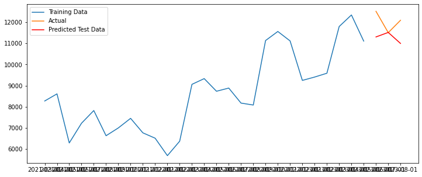

```python
plt.figure(figsize=(12, 5))
plt.plot(monthly_volume_train.index, monthly_volume_train['Contacts Received'], label='Training Data')
plt.plot(monthly_volume_test.index, monthly_volume_test['Contacts Received'], label='Actual')
plt.plot(monthly_volume_test.index, yhat.values, color='red', label='Predicted Test Data')
plt.legend()
```

```python
#Future 18 months
last_month_datetime = pd.to_datetime(monthly_volume.index[-1])
next_month_datetime = last_month_datetime + pd.DateOffset(months=1)
next_month_str = next_month_datetime.strftime('%Y-%m-%d')
next_month_str
new_months = pd.date_range(start=next_month_str, periods=18, freq='MS')
new_df = pd.DataFrame(index=new_months)
extended_df = pd.concat([monthly_volume, new_df])
```

```python
yhat = list()
for t in tqdm(range(18)):
    temp_train = extended_df[:len(monthly_volume)+t]

    s_monthly_model_fit = autoModel.fit(temp_train['Contacts Received'])


    predictions = s_monthly_model_fit.predict(
        start=len(temp_train), end=len(temp_train), dynamic=False)
    extended_df.iloc[t-18] = predictions.values[0]+100
    yhat = yhat + [predictions.values[0]+100]

#yhat
```

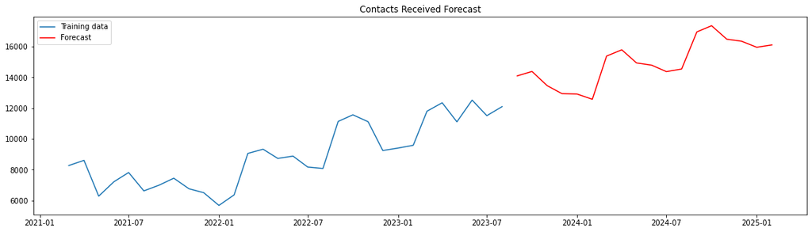

```python
plt.figure(figsize=(19, 5))
#Plotting the historical data
monthly_volume.index = pd.to_datetime(monthly_volume.index)
plt.plot(monthly_volume['Contacts Received'], label='Training data')


future_months= pd.date_range(start=next_month_datetime, periods=18, freq='MS')
#display(future_weeks)
plt.plot(future_months, yhat, color='red', label='Forecast')

#Plotting the confidence intervals
#plt.fill_between(pred_w, conf_int.iloc[:, 0], conf_int.iloc[:, 1], color='pink', alpha=0.3)

plt.title('Contacts Received Forecast')
plt.legend()
plt.show()
```

### Adjustment

```python
last_month_datetime = pd.to_datetime(monthly_volume.index[-1])
next_month_datetime = last_month_datetime + pd.DateOffset(months=1)
next_month_str = next_month_datetime.strftime('%Y-%m-%d')
new_months = pd.date_range(start=next_month_str, periods=18, freq='MS')
new_df = pd.DataFrame(index=new_months)
extended_df2 = extended_df[:18]
extended_df2 = pd.concat([extended_df2, new_df])
```

```python
yhat2 = list()
autoModel = pm.auto_arima(extended_df2[:17]['Contacts Received'], trace=True, error_action='ignore',
                          suppress_warnings=True, seasonal=True)
autoModel.fit(monthly_volume['Contacts Received'])
for t in tqdm(range(18)):
    temp_train = extended_df2[:17+t]

    s_monthly_model_fit = autoModel.fit(temp_train['Contacts Received'])


    predictions = s_monthly_model_fit.predict(
        start=len(temp_train), end=len(temp_train), dynamic=False)
    extended_df2.iloc[t-18] = predictions.values[0]+400
    yhat2 = yhat2 + [predictions.values[0]+400]

#yhat2
```

```
Performing stepwise search to minimize aic
 ARIMA(2,0,2)(0,0,0)[0] intercept   : AIC=inf, Time=0.06 sec
 ARIMA(0,0,0)(0,0,0)[0] intercept   : AIC=290.054, Time=0.01 sec
 ARIMA(1,0,0)(0,0,0)[0] intercept   : AIC=286.664, Time=0.02 sec
 ARIMA(0,0,1)(0,0,0)[0] intercept   : AIC=inf, Time=0.02 sec
 ARIMA(0,0,0)(0,0,0)[0]             : AIC=354.295, Time=0.00 sec
 ARIMA(2,0,0)(0,0,0)[0] intercept   : AIC=287.903, Time=0.02 sec
 ARIMA(1,0,1)(0,0,0)[0] intercept   : AIC=288.492, Time=0.01 sec
 ARIMA(2,0,1)(0,0,0)[0] intercept   : AIC=inf, Time=0.07 sec
 ARIMA(1,0,0)(0,0,0)[0]             : AIC=inf, Time=0.01 sec

Best model:  ARIMA(1,0,0)(0,0,0)[0] intercept
Total fit time: 0.221 seconds
```

```python
l=[]
for a,b,c in zip(yhat,yhat2,extended_df[17:35].values):
    l.append(a+c-b-2000)
#l
```

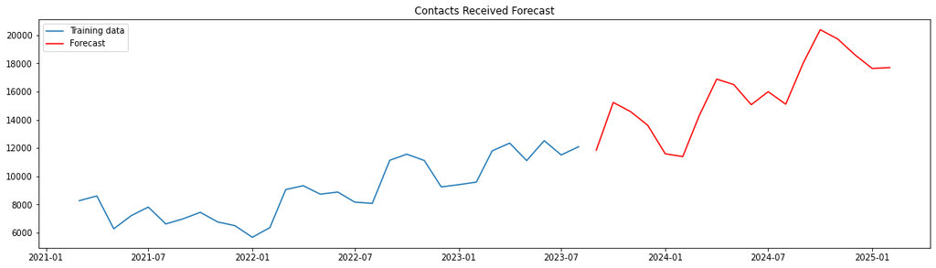

```python
plt.figure(figsize=(19, 5))

monthly_volume.index = pd.to_datetime(monthly_volume.index)
plt.plot(monthly_volume['Contacts Received'], label='Training data')
future_months= pd.date_range(start=next_month_datetime, periods=18, freq='MS')
plt.plot(future_months, l, color='red', label='Forecast')
plt.title('Contacts Received Forecast')
plt.legend()
plt.show()
```

```python
#next 18 months
next_best_18_months = pd.DataFrame({'Date': future_months, 'Contacts Received':l})
print(next_best_18_months)
```

```
         Date     Contacts Received
0  2023-09-01  [11845.428437519526]
1  2023-10-01  [15227.286023062235]
2  2023-11-01  [14569.550971375644]
3  2023-12-01    [13611.8505192263]
4  2024-01-01  [11591.987390114706]
5  2024-02-01   [11396.45111207128]
6  2024-03-01  [14288.079131652987]
7  2024-04-01   [16878.71539180797]
8  2024-05-01   [16494.82378418775]
9  2024-06-01   [15069.39646418338]
10 2024-07-01  [15987.104558176452]
11 2024-08-01  [15101.650490676227]
12 2024-09-01   [18026.59713546653]
13 2024-10-01   [20376.69795578502]
14 2024-11-01   [19717.62909480965]
15 2024-12-01  [18608.853841367003]
16 2025-01-01   [17630.59381011198]
17 2025-02-01  [17694.250743589233]
```

### 5.3.1 ARIMA

```python
monthly_aht = monthly[['Year-Month','AHT of Handled Contacts']]
monthly_aht = monthly_aht.set_index('Year-Month')
monthly_aht.index = monthly_aht.index.to_timestamp().strftime('%Y-%m-%d')
```

```python
#train_test_split
monthly_aht_train = monthly_aht.iloc[0:27]
monthly_aht_test = monthly_aht[27:]
```

```python
autoModel = pm.auto_arima(monthly_aht_train['AHT of Handled Contacts'], trace=True, error_action='ignore',
                          suppress_warnings=True, seasonal=True)
autoModel.fit(monthly_aht_train['AHT of Handled Contacts'])
```

```
Performing stepwise search to minimize aic
 ARIMA(2,0,2)(0,0,0)[0] intercept   : AIC=278.684, Time=0.08 sec
 ARIMA(0,0,0)(0,0,0)[0] intercept   : AIC=284.185, Time=0.01 sec
 ARIMA(1,0,0)(0,0,0)[0] intercept   : AIC=278.802, Time=0.02 sec
 ARIMA(0,0,1)(0,0,0)[0] intercept   : AIC=274.085, Time=0.02 sec
 ARIMA(0,0,0)(0,0,0)[0]             : AIC=447.265, Time=0.01 sec
 ARIMA(1,0,1)(0,0,0)[0] intercept   : AIC=275.679, Time=0.04 sec
 ARIMA(0,0,2)(0,0,0)[0] intercept   : AIC=275.224, Time=0.03 sec
 ARIMA(1,0,2)(0,0,0)[0] intercept   : AIC=277.213, Time=0.06 sec
 ARIMA(0,0,1)(0,0,0)[0]             : AIC=inf, Time=0.02 sec

Best model:  ARIMA(0,0,1)(0,0,0)[0] intercept
Total fit time: 0.284 seconds
```

```
ARIMA(order=(0, 0, 1), scoring_args={}, suppress_warnings=True)
```

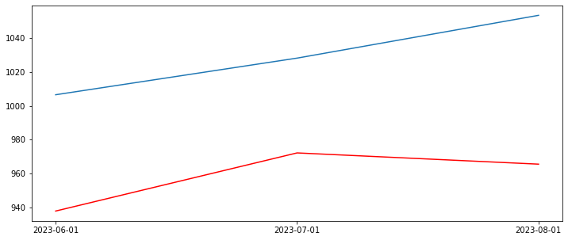

```python
order = autoModel.order
yhat = list()
for t in tqdm(range(len(monthly_aht_test['AHT of Handled Contacts']))):
    temp_train = monthly_aht[:len(monthly_volume_train)+t]
    model = ARIMA(temp_train['AHT of Handled Contacts'], order=order)
    monthly_aht_model_fit = model.fit()
    predictions = monthly_aht_model_fit.predict(
        start=len(temp_train), end=len(temp_train), dynamic=False)
    yhat = yhat + [predictions]

yhat = pd.concat(yhat)

#yhat
plt.figure(figsize=(12, 5))
plt.plot(monthly_aht_test.index, monthly_aht_test['AHT of Handled Contacts'], label='Actual')
plt.plot(monthly_aht_test.index, yhat.values, color='red', label='Predicted Test Data')
```

```python
mae = mean_absolute_error(monthly_aht_test['AHT of Handled Contacts'], yhat.values)
print(f'The mae of model is:{mae}.')
ape = np.abs((monthly_aht_test['AHT of Handled Contacts'] - yhat.values) / monthly_aht_test['AHT of Handled Contacts'])
mape=np.mean(ape)
print(f'The mape of model is:{mape}.')
```

```
The mae of model is:70.95131403495343.
The mape of model is:0.06880085531545638.
```

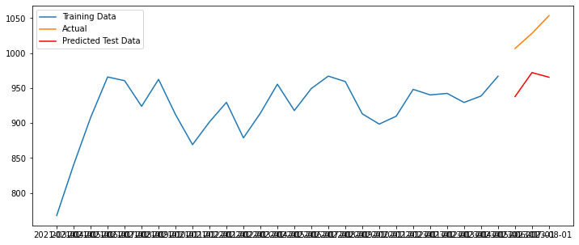

```python
plt.figure(figsize=(12, 5))
plt.plot(monthly_aht_train.index, monthly_aht_train['AHT of Handled Contacts'], label='Training Data')
plt.plot(monthly_aht_test.index, monthly_aht_test['AHT of Handled Contacts'], label='Actual')
plt.plot(monthly_aht_test.index, yhat.values, color='red', label='Predicted Test Data')
plt.legend()
```

```python
#Future 16 months

last_month_datetime = pd.to_datetime(monthly_aht.index[-1])
next_month_datetime = last_month_datetime + pd.DateOffset(months=1)
next_month_str = next_month_datetime.strftime('%Y-%m-%d')
new_months = pd.date_range(start=next_month_str, periods=16, freq='MS')
new_df = pd.DataFrame(index=new_months)
extended_df = pd.concat([monthly_aht, new_df])
```

```python
yhat = list()
for t in tqdm(range(16)):
    temp_train = extended_df[:len(monthly_aht)+t]

    monthly_aht_model_fit = autoModel.fit(temp_train['AHT of Handled Contacts'])
    predictions = monthly_aht_model_fit.predict(
        start=len(temp_train), end=len(temp_train), dynamic=False)
    extended_df.iloc[t-16] = predictions.values[0]+120
    yhat = yhat + [predictions.values[0]+120]

#yhat
```

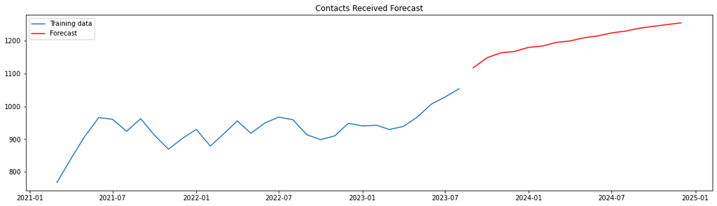

```python
plt.figure(figsize=(19, 5))
monthly_aht.index = pd.to_datetime(monthly_aht.index)
plt.plot(monthly_aht['AHT of Handled Contacts'], label='Training data')
future_months= pd.date_range(start=next_month_datetime, periods=16, freq='MS')
plt.plot(future_months, yhat, color='red', label='Forecast')
plt.title('Contacts Received Forecast')
plt.legend()
plt.show()
```